# Data Camp / Intro to Time Series Analysis - Chapter 4

Initialize and load the data

Chapter 4 of [Data Camp - Intro to Time Series Analsys](https://www.datacamp.com/courses/introduction-to-time-series-analysis)

### Autoregressive model (AR)

**See supplemental slides for details**

To create an AR model use the `arima.sim()` function and specify the *slope* with the *mode = list(ar=**mu**)*.

Simplest case is the Model - 1.

The AR recursion is

*Today = Constant + Slope * Yesterday + Noise*

Mean centerd version:

*(Today - Mean) = Slope * (Yesterda - Mean) + Noise*

Or

$Y_t - \mu = \phi(Y_{t-1} - \mu) + \epsilon_t$ where $\epsilon_t$ is mean zero WN.

3 Parms:

- Mean $\mu$
- Slope $\phi$
- The WN variace $\sigma_{\epsilon}^2$

If $\phi = 0$ then $Y_t = \mu + \epsilon_t$ and $Y_t$ is White Noise $(\mu, \sigma_{\epsilon}^2)$.

If $\phi \ne 0$ then $Y_t$ depends on both $\epsilon_t$ and $Y_{t-1}$ and the process ${Y_t}$ is autocorrelated.

- Large values of $\phi$ lead to greater correlation
- Negative values of $\phi$ lead to oscillatory ts.

### Random Walk

If $\mu = 0$ and slope $\phi = 1$ then $Y_t = Y_{t-1} + \epsilon_t$ which is Random Walk.

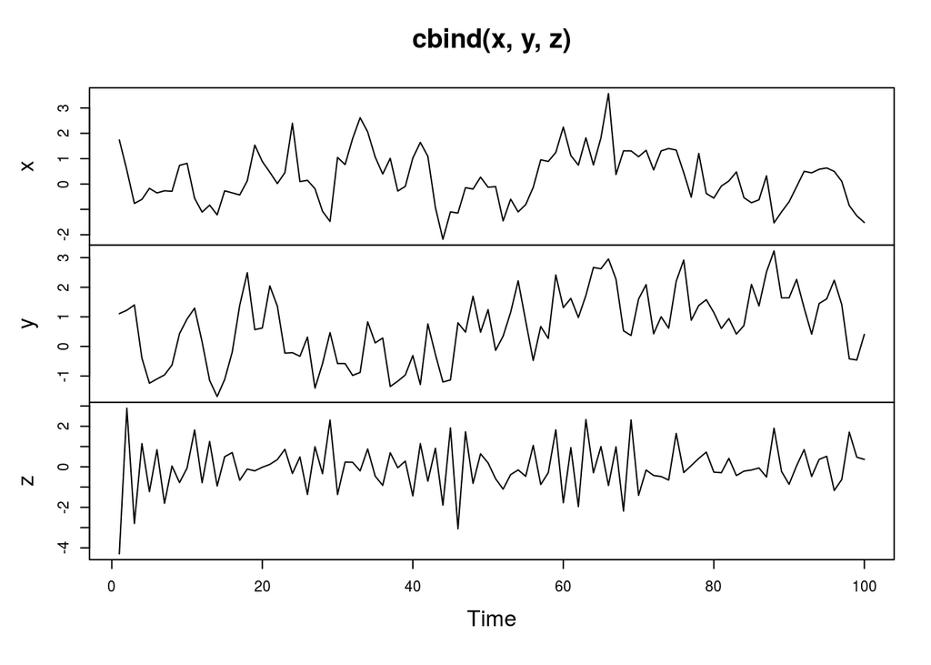

```r
x <- arima.sim(model=list(ar=0.5), n=100)

# Simulate an AR model with 0.9 slope
y <- arima.sim(model=list(ar=0.9), n=100)

# Simulate an AR model with -0.75 slope
z <- arima.sim(model=list(ar=(-0.75)), n=100)

# Plot your simulated data
plot.ts(cbind(x, y, z))
```

# ACF

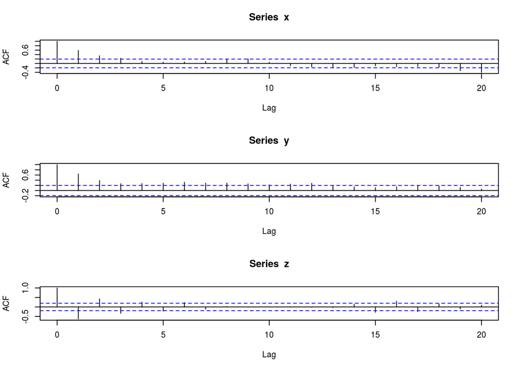

```r
par(mfrow=c(3,1))
acf(x)
acf(y)
acf(z)
```

### Persistence / AntiPersistence

- Persistence is defined by high correlation between an observation and its lag.
- Antipersistence is defined by a large amount of variation between an observation and it’s lag.

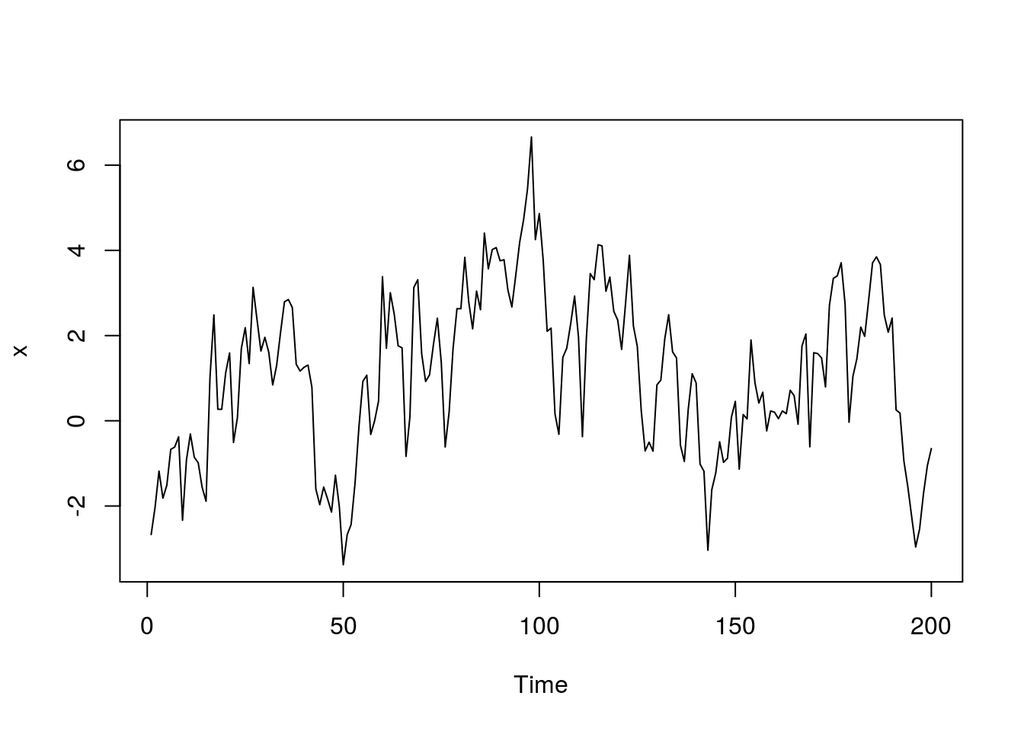

```r
x <- arima.sim(model = list(ar=0.9), n = 200)
ts.plot(x)
```

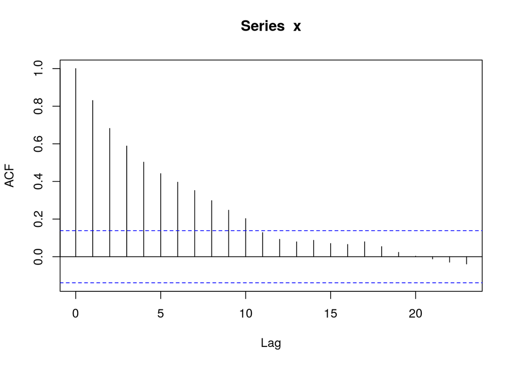

```r
acf(x)
```

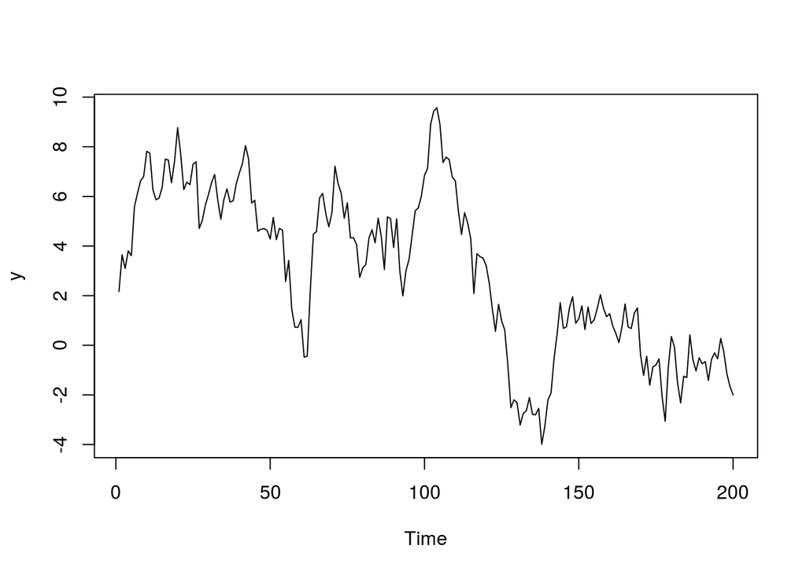

```r
# Simulate and plot AR model with slope 0.98
y <- arima.sim(model=list(ar=0.98), n=200)
ts.plot(y)
```

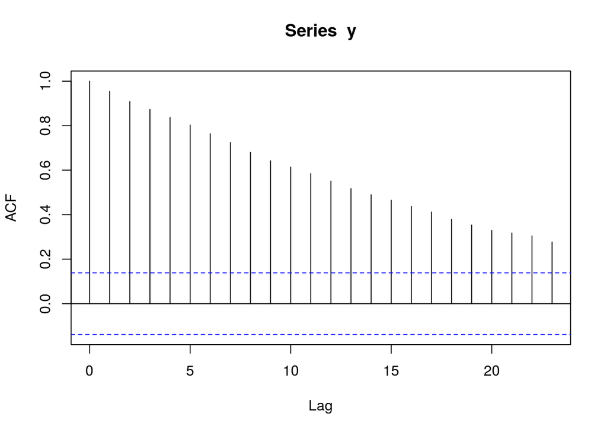

```r
acf(y)
```

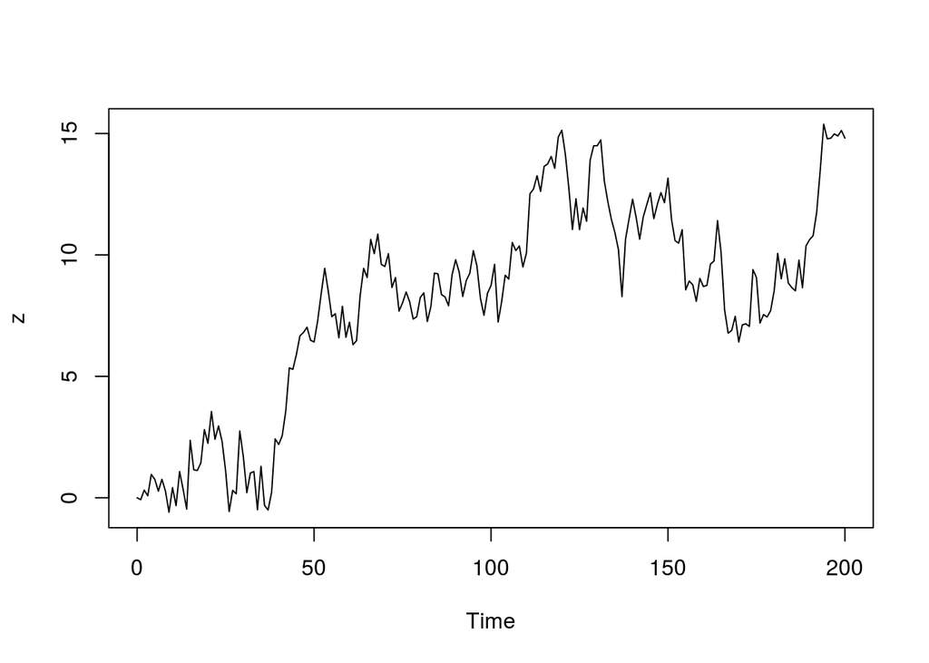

```r
# Simulate and plot RW model
z <- arima.sim(model=list(order=c(0,1,0)), n=200)
ts.plot(z)
```

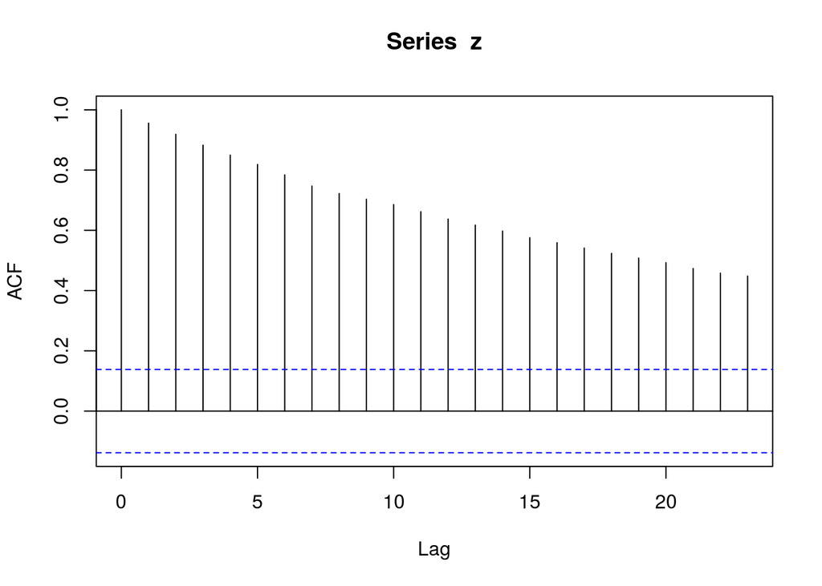

```r
acf(z)
```

### AR Model Estimating and Forecasting

an AR model is ARIMA(1, 0, 0)

Let’s fit an arima model to *AirPassengers* and plot it as well as teh fited values.

The fitted values are simply the original data less the residuals, which can be extracted with the `residuals()` function.

```r
data("AirPassengers")

AR <- arima(AirPassengers, order=c(1, 0, 0))
print(AR)
```

```
##
## Call:
## arima(x = AirPassengers, order = c(1, 0, 0))
##
## Coefficients:
##          ar1  intercept
##       0.9669   275.5774
## s.e.  0.0207    68.2627
##
## sigma^2 estimated as 1035:  log likelihood = -705.52,  aic = 1417.04
```

[figure not shown]

```r
ts.plot(AirPassengers)
AR_fitted <- AirPassengers - residuals(AR)
points(AR_fitted, type = "l", col = 2, lty = 2)
```

### Simple forecasts

The `predict()` function is used to predict the future!

```r
data("Nile")

AR_fit <-arima(Nile, order  = c(1, 0, 0))
print(AR_fit)
```

```
##
## Call:
## arima(x = Nile, order = c(1, 0, 0))
##
## Coefficients:
##          ar1  intercept
##       0.5063   919.5685
## s.e.  0.0867    29.1410
##
## sigma^2 estimated as 21125:  log likelihood = -639.95,  aic = 1285.9
```

```r
# Use predict() to make a 1-step forecast
predict_AR <- predict(AR_fit)

# Obtain the 1-step forecast using $pred[1]
predict_AR$pred[1]
```

```
## [1] 828.6576
```

```r
# Use predict to make 1-step through 10-step forecasts
predict(AR_fit, n.ahead = 10)
```

```
## $pred
## Time Series:
## Start = 1971
## End = 1980
## Frequency = 1
##  [1] 828.6576 873.5426 896.2668 907.7715 913.5960 916.5448 918.0377
##  [8] 918.7935 919.1762 919.3699
##
## $se
## Time Series:
## Start = 1971
## End = 1980
## Frequency = 1
##  [1] 145.3439 162.9092 167.1145 168.1754 168.4463 168.5156 168.5334
##  [8] 168.5380 168.5391 168.5394
```

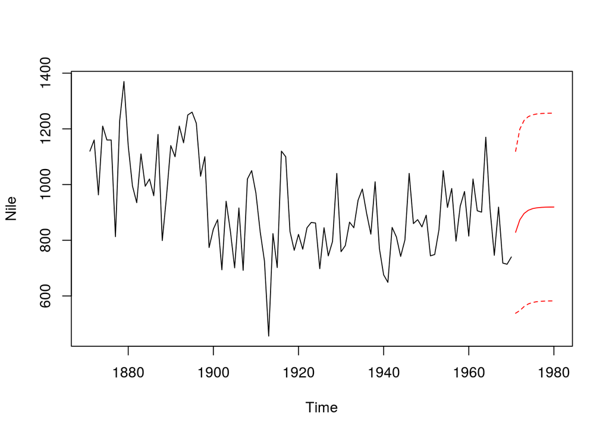

```r
# Run to plot the Nile series plus the forecast and 95% prediction intervals
ts.plot(Nile, xlim = c(1871, 1980))
AR_forecast <- predict(AR_fit, n.ahead = 10)$pred
AR_forecast_se <- predict(AR_fit, n.ahead = 10)$se
points(AR_forecast, type = "l", col = 2)
points(AR_forecast - 2*AR_forecast_se, type = "l", col = 2, lty = 2)
points(AR_forecast + 2*AR_forecast_se, type = "l", col = 2, lty = 2)
```